# Complete: Infer ASVs with DADA2

Marian Schmidt

March 06, 2024

# Before you start

## Set my seed

```r
# Any number can be chosen
set.seed(238428)
```

## Symbolically link data

Run the following commands in your shell to symbolically link the fastq files to the current repository.

```bash
cd git_repos/repo
mkdir data
cd data
mkdir 01_DADA2
cd 01_DADA2
mkdir 01_raw_gzipped_fastqs

#for FILE in `ls /workdir/in_class_data/SalinityGradient_16S/raw_gzipped_fastqs/*.fastq.gz`
for FILE in `ls /workdir/in_class_data/raw_gzipped_seqs/*.fastq.gz`
  do
  ln -s $FILE /workdir/mls528/git_repos/SalinityGradient_16S/data/01_DADA2/01_raw_gzipped_fastqs/
  done
```

# Goals of this file

**NOTE:** This document was **NOT** run during class. Instead, it was run as an example to navigate the issues with the server crashing during the dada2 workflow.

1. Use raw fastq files and generate quality plots to assess quality of reads.
2. Filter and trim out bad sequences and bases from our sequencing files.
3. Write out fastq files with high quality sequences.
4. Evaluate the quality from our filter and trim.
5. Infer Errors on forward and reverse reads individually.
6. Identified ASVs on forward and reverse reads separately, using the error model.
7. Merge forward and reverse ASVs into “contiguous ASVs”.
8. Generate the ASV count table. (`otu_table` input for phyloseq.).

Output that we need:

1. ASV Count Table: `otu_table`
2. Taxonomy Table `tax_table`
3. Sample Information: `sample_data` track the reads lots throughout DADA2 workflow.

# Load Libraries

```r
# Efficient package loading with pacman
# Don't forget to install pacman and DT if you don't have it yet. :)
pacman::p_load(tidyverse, devtools, dada2, phyloseq, patchwork, DT,
               install = FALSE)
```

# Load Data

```r
# Set the raw fastq path to the raw sequencing files
# Path to the fastq files
raw_fastqs_path <- "data/01_DADA2/01_raw_gzipped_fastqs"
raw_fastqs_path
```

```
## [1] "data/01_DADA2/01_raw_gzipped_fastqs"
```

```r
# What files are in this path? Intuition Check
head(list.files(raw_fastqs_path))
```

```
## [1] "022um-Control_S36_L001_R1_001.fastq.gz"
## [2] "022um-Control_S36_L001_R2_001.fastq.gz"
## [3] "20210602-MA-ABB1F_S31_L001_R1_001.fastq.gz"
## [4] "20210602-MA-ABB1F_S31_L001_R2_001.fastq.gz"
## [5] "20210602-MA-ABB1P_S28_L001_R1_001.fastq.gz"
## [6] "20210602-MA-ABB1P_S28_L001_R2_001.fastq.gz"
```

```r
# How many files are there?
str(list.files(raw_fastqs_path))
```

```
##  chr [1:190] "022um-Control_S36_L001_R1_001.fastq.gz" ...
```

```r
# Create vector of forward reads
forward_reads <- list.files(raw_fastqs_path, pattern = "R1_001.fastq.gz", full.names = TRUE)
# Intuition Check
head(forward_reads)
```

```
## [1] "data/01_DADA2/01_raw_gzipped_fastqs/022um-Control_S36_L001_R1_001.fastq.gz"
## [2] "data/01_DADA2/01_raw_gzipped_fastqs/20210602-MA-ABB1F_S31_L001_R1_001.fastq.gz"
## [3] "data/01_DADA2/01_raw_gzipped_fastqs/20210602-MA-ABB1P_S28_L001_R1_001.fastq.gz"
## [4] "data/01_DADA2/01_raw_gzipped_fastqs/20210602-MA-ABB1W_S58_L001_R1_001.fastq.gz"
## [5] "data/01_DADA2/01_raw_gzipped_fastqs/20210602-MA-ABS1F_S45_L001_R1_001.fastq.gz"
## [6] "data/01_DADA2/01_raw_gzipped_fastqs/20210602-MA-ABS1P_S65_L001_R1_001.fastq.gz"
```

```r
# Create a vector of reverse reads
reverse_reads <- list.files(raw_fastqs_path, pattern = "R2_001.fastq.gz", full.names = TRUE)
head(reverse_reads)
```

```
## [1] "data/01_DADA2/01_raw_gzipped_fastqs/022um-Control_S36_L001_R2_001.fastq.gz"
## [2] "data/01_DADA2/01_raw_gzipped_fastqs/20210602-MA-ABB1F_S31_L001_R2_001.fastq.gz"
## [3] "data/01_DADA2/01_raw_gzipped_fastqs/20210602-MA-ABB1P_S28_L001_R2_001.fastq.gz"
## [4] "data/01_DADA2/01_raw_gzipped_fastqs/20210602-MA-ABB1W_S58_L001_R2_001.fastq.gz"
## [5] "data/01_DADA2/01_raw_gzipped_fastqs/20210602-MA-ABS1F_S45_L001_R2_001.fastq.gz"
## [6] "data/01_DADA2/01_raw_gzipped_fastqs/20210602-MA-ABS1P_S65_L001_R2_001.fastq.gz"
```

# Assess Raw Read Quality

## Evaluate raw sequence quality

Let’s see the quality of the raw reads *before* we trim

### Plot 12 random samples of plots

```r
# Randomly select 12 samples from dataset to evaluate
# Selecting 12 is typically better than 2 (like we did in class for efficiency)
random_samples <- sample(1:length(reverse_reads), size = 12)
random_samples
```

```
##  [1] 59 45 49 80 40 68  8 43 89  5 55 67
```

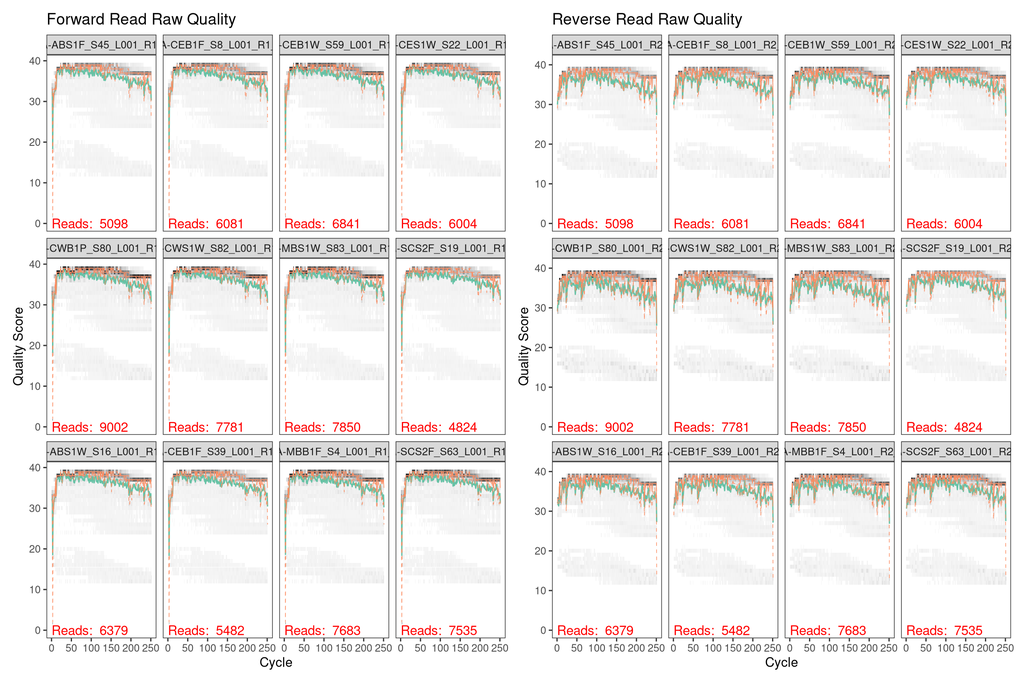

```r
# Calculate and plot quality of these two samples
forward_filteredQual_plot_12 <- plotQualityProfile(forward_reads[random_samples]) +
  labs(title = "Forward Read Raw Quality")
reverse_filteredQual_plot_12 <- plotQualityProfile(reverse_reads[random_samples]) +
  labs(title = "Reverse Read Raw Quality")


# Plot them together with patchwork
forward_filteredQual_plot_12 + reverse_filteredQual_plot_12
```

### Aggregated Raw Quality Plots

```r
# Aggregate all QC plots
plotQualityProfile(forward_reads, aggregate = TRUE) +
  plotQualityProfile(forward_reads, aggregate = TRUE)
```

[output not shown]

## Prepare a placeholder for filtered reads

```r
# vector of our samples, extract sample name from files
samples <- sapply(strsplit(basename(forward_reads), "_"), `[`,1)
# Intuition Check
head(samples)
```

```
## [1] "022um-Control"     "20210602-MA-ABB1F" "20210602-MA-ABB1P"
## [4] "20210602-MA-ABB1W" "20210602-MA-ABS1F" "20210602-MA-ABS1P"
```

```r
# Place filtered reads into filtered_fastqs_path
filtered_fastqs_path <- "data/01_DADA2/02_filtered_fastqs"
filtered_fastqs_path
```

```
## [1] "data/01_DADA2/02_filtered_fastqs"
```

```r
# create 2 variables: filtered_F, filtered_R
filtered_forward_reads <-
  file.path(filtered_fastqs_path, paste0(samples, "_R1_filtered.fastq.gz"))
length(filtered_forward_reads)
```

```
## [1] 95
```

```r
# reverse reads
filtered_reverse_reads <-
  file.path(filtered_fastqs_path, paste0(samples, "_R2_filtered.fastq.gz"))
head(filtered_reverse_reads)
```

```
## [1] "data/01_DADA2/02_filtered_fastqs/022um-Control_R2_filtered.fastq.gz"
## [2] "data/01_DADA2/02_filtered_fastqs/20210602-MA-ABB1F_R2_filtered.fastq.gz"
## [3] "data/01_DADA2/02_filtered_fastqs/20210602-MA-ABB1P_R2_filtered.fastq.gz"
## [4] "data/01_DADA2/02_filtered_fastqs/20210602-MA-ABB1W_R2_filtered.fastq.gz"
## [5] "data/01_DADA2/02_filtered_fastqs/20210602-MA-ABS1F_R2_filtered.fastq.gz"
## [6] "data/01_DADA2/02_filtered_fastqs/20210602-MA-ABS1P_R2_filtered.fastq.gz"
```

# Filter and Trim Reads

Parameters of filter and trim **DEPEND ON THE DATASET**

- `maxN` = number of N bases. Remove all Ns from the data.
- `maxEE` = Quality filtering threshold applied to expected errors. Here, if there’s 2 expected errors. It’s ok. But more than 2. Throw away the sequence. Two values, first is for forward reads; second is for reverse reads.
- `trimLeft` = remove first three basepairs.

```r
# Assign a vector to filtered reads
# trim out poor bases, first 3 bps on F reads
# write out filtered fastq files
filtered_reads <-
  filterAndTrim(fwd = forward_reads, filt = filtered_forward_reads,
              rev = reverse_reads, filt.rev = filtered_reverse_reads,
              maxN = 0, maxEE = c(2,2), trimLeft = 3,
              truncQ = 2, rm.phix = TRUE, compress = TRUE, multithread = TRUE)
```

# Assess Trimmed Read Quality

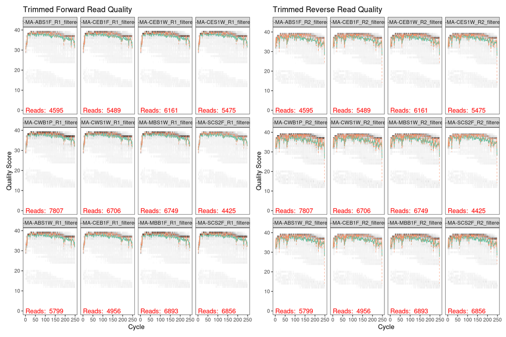

```r
# Plot the 12 random samples after QC
forward_filteredQual_plot_12 <-
  plotQualityProfile(filtered_forward_reads[random_samples]) +
  labs(title = "Trimmed Forward Read Quality")

reverse_filteredQual_plot_12 <-
  plotQualityProfile(filtered_reverse_reads[random_samples]) +
  labs(title = "Trimmed Reverse Read Quality")

# Put the two plots together
forward_filteredQual_plot_12 + reverse_filteredQual_plot_12
```

## Aggregated Trimmed Plots

```r
# Aggregate all QC plots
plotQualityProfile(filtered_forward_reads, aggregate = TRUE) +
  plotQualityProfile(filtered_reverse_reads, aggregate = TRUE)
```

[output not shown]

## Stats on read output from `filterAndTrim`

```r
# Make output into dataframe
filtered_df <- as.data.frame(filtered_reads)
head(filtered_df)
```

```
##                                            reads.in reads.out
## 022um-Control_S36_L001_R1_001.fastq.gz         8722      8023
## 20210602-MA-ABB1F_S31_L001_R1_001.fastq.gz     5156      4632
## 20210602-MA-ABB1P_S28_L001_R1_001.fastq.gz     5051      4597
## 20210602-MA-ABB1W_S58_L001_R1_001.fastq.gz     7695      7023
## 20210602-MA-ABS1F_S45_L001_R1_001.fastq.gz     5098      4595
## 20210602-MA-ABS1P_S65_L001_R1_001.fastq.gz     5900      5314
```

```r
# calculate some stats
filtered_df %>%
  reframe(median_reads_in = median(reads.in),
          median_reads_out = median(reads.out),
          median_percent_retained = (median(reads.out)/median(reads.in)))
```

```
##   median_reads_in median_reads_out median_percent_retained
## 1            6623             5859               0.8846444
```

- How many reads got through? Is it “enough”?
- Should you play with the paratmeters in `filterAndTrim()` more? If so, which parameters?

# Error Modelling

**Note every sequencing run needs to be run separately!** The error model *MUST* be run separately on each illumina dataset. If you’d like to combine the datasets from multiple sequencing runs, you’ll need to do the exact same `filterAndTrim()` step *AND*, very importantly, you’ll need to have the same primer and ASV length expected by the output.

Infer error rates for all possible transitions within purines and pyrimidines (A<>G or C<>T) and transversions between all purine and pyrimidine combinations.

Error model is learned by alternating estimation of the error rates and inference of sample composition until they converge.

1. Starts with the assumption that the error rates are the maximum (takes the most abundant sequence (“center”) and assumes it’s the only sequence not caused by errors).
2. Compares the other sequences to the most abundant sequence.
3. Uses at most 10<sup>8</sup> nucleotides for the error estimation.
4. Uses parametric error estimation function of loess fit on the observed error rates.

## Learn the errors

```r
# Forward reads
error_forward_reads <-
  learnErrors(filtered_forward_reads, multithread = TRUE)
```

```
## 101513344 total bases in 409328 reads from 71 samples will be used for learning the error rates.
```

```r
# Plot Forward
forward_error_plot <-
  plotErrors(error_forward_reads, nominalQ = TRUE) +
  labs(title = "Forward Read Error Model")

# Reverse reads
error_reverse_reads <-
  learnErrors(filtered_reverse_reads, multithread = TRUE)
```

```
## 101513344 total bases in 409328 reads from 71 samples will be used for learning the error rates.
```

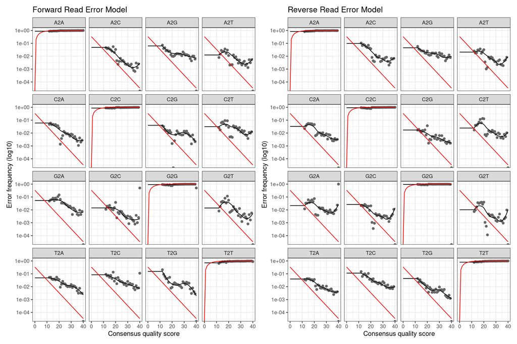

```r
# Plot reverse
reverse_error_plot <-
  plotErrors(error_reverse_reads, nominalQ = TRUE) +
  labs(title = "Reverse Read Error Model")

# Put the two plots together
forward_error_plot + reverse_error_plot
```

- The error rates for each possible transition (A→C, A→G, …) are shown in the plot above.

Details of the plot: - **Points**: The observed error rates for each consensus quality score.  
- **Black line**: Estimated error rates after convergence of the machine-learning algorithm.  
- **Red line:** The error rates expected under the nominal definition of the Q-score.

Similar to what is mentioned in the dada2 tutorial: the estimated error rates (black line) are a “reasonably good” fit to the observed rates (points), and the error rates drop with increased quality as expected. We can now infer ASVs!

# Infer ASVs

**An important note:** This process occurs separately on forward and reverse reads! This is quite a different approach from how OTUs are identified in Mothur and also from UCHIME, oligotyping, and other OTU, MED, and ASV approaches.

```r
# Infer ASVs on the forward sequences
dada_forward <- dada(filtered_forward_reads,
                     err = error_forward_reads,
                     multithread = TRUE)
```

```
## Sample 1 - 8023 reads in 903 unique sequences.
## Sample 2 - 4632 reads in 1691 unique sequences.
## Sample 3 - 4597 reads in 2340 unique sequences.
## Sample 4 - 7023 reads in 3070 unique sequences.
## Sample 5 - 4595 reads in 2108 unique sequences.
## Sample 6 - 5314 reads in 2688 unique sequences.
## Sample 7 - 6145 reads in 2899 unique sequences.
## Sample 8 - 5489 reads in 2473 unique sequences.
## Sample 9 - 6954 reads in 2989 unique sequences.
## Sample 10 - 6599 reads in 3046 unique sequences.
## Sample 11 - 5869 reads in 2320 unique sequences.
## Sample 12 - 5632 reads in 2336 unique sequences.
## Sample 13 - 5157 reads in 2130 unique sequences.
## Sample 14 - 3708 reads in 2027 unique sequences.
## Sample 15 - 5753 reads in 2707 unique sequences.
## Sample 16 - 6743 reads in 3242 unique sequences.
## Sample 17 - 5750 reads in 3452 unique sequences.
## Sample 18 - 4411 reads in 2735 unique sequences.
## Sample 19 - 6351 reads in 3734 unique sequences.
## Sample 20 - 6745 reads in 2383 unique sequences.
## Sample 21 - 3451 reads in 1560 unique sequences.
## Sample 22 - 4551 reads in 1837 unique sequences.
## Sample 23 - 6094 reads in 2284 unique sequences.
## Sample 24 - 3506 reads in 1118 unique sequences.
## Sample 25 - 5268 reads in 2153 unique sequences.
## Sample 26 - 5436 reads in 2596 unique sequences.
## Sample 27 - 4199 reads in 2246 unique sequences.
## Sample 28 - 6156 reads in 2902 unique sequences.
## Sample 29 - 8615 reads in 3723 unique sequences.
## Sample 30 - 7402 reads in 3618 unique sequences.
## Sample 31 - 4346 reads in 2061 unique sequences.
## Sample 32 - 3132 reads in 619 unique sequences.
## Sample 33 - 4600 reads in 2251 unique sequences.
## Sample 34 - 9349 reads in 3907 unique sequences.
## Sample 35 - 4949 reads in 2193 unique sequences.
## Sample 36 - 6222 reads in 2872 unique sequences.
## Sample 37 - 4559 reads in 2025 unique sequences.
## Sample 38 - 6836 reads in 2887 unique sequences.
## Sample 39 - 5054 reads in 2434 unique sequences.
## Sample 40 - 6161 reads in 2679 unique sequences.
```

[output cut: 40 more lines]

```
## Sample 81 - 9379 reads in 4255 unique sequences.
## Sample 82 - 9434 reads in 3987 unique sequences.
## Sample 83 - 5833 reads in 2520 unique sequences.
## Sample 84 - 5721 reads in 2747 unique sequences.
## Sample 85 - 7277 reads in 3185 unique sequences.
## Sample 86 - 7954 reads in 3133 unique sequences.
## Sample 87 - 6338 reads in 2723 unique sequences.
## Sample 88 - 7778 reads in 4114 unique sequences.
## Sample 89 - 6856 reads in 2734 unique sequences.
## Sample 90 - 6215 reads in 1967 unique sequences.
## Sample 91 - 6455 reads in 2584 unique sequences.
## Sample 92 - 8770 reads in 985 unique sequences.
## Sample 93 - 6095 reads in 788 unique sequences.
## Sample 94 - 7038 reads in 3146 unique sequences.
## Sample 95 - 9520 reads in 966 unique sequences.
```

```r
typeof(dada_forward)
```

```
## [1] "list"
```

```r
# Grab a sample and look at it
dada_forward$`20211005-MA-CWS1P_R1_filtered.fastq.gz`
```

```
## dada-class: object describing DADA2 denoising results
## 241 sequence variants were inferred from 2916 input unique sequences.
## Key parameters: OMEGA_A = 1e-40, OMEGA_C = 1e-40, BAND_SIZE = 16
```

```r
# Infer ASVs on the reverse sequences
dada_reverse <- dada(filtered_reverse_reads,
                     err = error_reverse_reads,
                     multithread = TRUE)
```

```
## Sample 1 - 8023 reads in 1355 unique sequences.
## Sample 2 - 4632 reads in 1911 unique sequences.
## Sample 3 - 4597 reads in 2539 unique sequences.
## Sample 4 - 7023 reads in 3424 unique sequences.
## Sample 5 - 4595 reads in 2419 unique sequences.
## Sample 6 - 5314 reads in 2921 unique sequences.
## Sample 7 - 6145 reads in 3182 unique sequences.
## Sample 8 - 5489 reads in 2689 unique sequences.
## Sample 9 - 6954 reads in 3398 unique sequences.
## Sample 10 - 6599 reads in 3342 unique sequences.
## Sample 11 - 5869 reads in 2849 unique sequences.
## Sample 12 - 5632 reads in 2649 unique sequences.
## Sample 13 - 5157 reads in 2481 unique sequences.
## Sample 14 - 3708 reads in 2211 unique sequences.
## Sample 15 - 5753 reads in 3005 unique sequences.
## Sample 16 - 6743 reads in 3589 unique sequences.
## Sample 17 - 5750 reads in 3827 unique sequences.
## Sample 18 - 4411 reads in 3091 unique sequences.
## Sample 19 - 6351 reads in 3971 unique sequences.
## Sample 20 - 6745 reads in 2630 unique sequences.
## Sample 21 - 3451 reads in 1745 unique sequences.
## Sample 22 - 4551 reads in 2079 unique sequences.
## Sample 23 - 6094 reads in 2555 unique sequences.
## Sample 24 - 3506 reads in 1336 unique sequences.
## Sample 25 - 5268 reads in 2483 unique sequences.
## Sample 26 - 5436 reads in 2830 unique sequences.
## Sample 27 - 4199 reads in 2425 unique sequences.
## Sample 28 - 6156 reads in 3180 unique sequences.
## Sample 29 - 8615 reads in 4131 unique sequences.
## Sample 30 - 7402 reads in 4064 unique sequences.
## Sample 31 - 4346 reads in 2313 unique sequences.
## Sample 32 - 3132 reads in 769 unique sequences.
## Sample 33 - 4600 reads in 2464 unique sequences.
## Sample 34 - 9349 reads in 4317 unique sequences.
## Sample 35 - 4949 reads in 2408 unique sequences.
## Sample 36 - 6222 reads in 3200 unique sequences.
## Sample 37 - 4559 reads in 2209 unique sequences.
## Sample 38 - 6836 reads in 3185 unique sequences.
## Sample 39 - 5054 reads in 2664 unique sequences.
## Sample 40 - 6161 reads in 2999 unique sequences.
```

[output cut: 40 more lines]

```
## Sample 81 - 9379 reads in 4696 unique sequences.
## Sample 82 - 9434 reads in 4325 unique sequences.
## Sample 83 - 5833 reads in 2936 unique sequences.
## Sample 84 - 5721 reads in 3029 unique sequences.
## Sample 85 - 7277 reads in 3561 unique sequences.
## Sample 86 - 7954 reads in 3504 unique sequences.
## Sample 87 - 6338 reads in 3082 unique sequences.
## Sample 88 - 7778 reads in 4504 unique sequences.
## Sample 89 - 6856 reads in 3046 unique sequences.
## Sample 90 - 6215 reads in 2351 unique sequences.
## Sample 91 - 6455 reads in 3231 unique sequences.
## Sample 92 - 8770 reads in 1547 unique sequences.
## Sample 93 - 6095 reads in 1163 unique sequences.
## Sample 94 - 7038 reads in 3304 unique sequences.
## Sample 95 - 9520 reads in 1551 unique sequences.
```

```r
# Inspect
dada_reverse[1]
```

```
## $`022um-Control_R2_filtered.fastq.gz`
## dada-class: object describing DADA2 denoising results
## 9 sequence variants were inferred from 1355 input unique sequences.
## Key parameters: OMEGA_A = 1e-40, OMEGA_C = 1e-40, BAND_SIZE = 16
```

```r
dada_reverse[30]
```

```
## $`20210602-MA-SCS1P_R2_filtered.fastq.gz`
## dada-class: object describing DADA2 denoising results
## 218 sequence variants were inferred from 4064 input unique sequences.
## Key parameters: OMEGA_A = 1e-40, OMEGA_C = 1e-40, BAND_SIZE = 16
```

# Merge Forward & Reverse ASVs

Now, merge the forward and reverse ASVs into contigs.

```r
# merge forward and reverse ASVs
merged_ASVs <- mergePairs(dada_forward, filtered_forward_reads,
                          dada_reverse, filtered_reverse_reads,
                          verbose = TRUE)
```

```
## 7972 paired-reads (in 9 unique pairings) successfully merged out of 7972 (in 9 pairings) input.
```

```
## 4166 paired-reads (in 154 unique pairings) successfully merged out of 4313 (in 194 pairings) input.
```

```
## 3702 paired-reads (in 155 unique pairings) successfully merged out of 3896 (in 209 pairings) input.
```

```
## 6087 paired-reads (in 177 unique pairings) successfully merged out of 6318 (in 230 pairings) input.
```

```
## 3922 paired-reads (in 135 unique pairings) successfully merged out of 4104 (in 175 pairings) input.
```

```
## 4335 paired-reads (in 162 unique pairings) successfully merged out of 4509 (in 219 pairings) input.
```

```
## 5236 paired-reads (in 164 unique pairings) successfully merged out of 5517 (in 228 pairings) input.
```

```
## 4816 paired-reads (in 153 unique pairings) successfully merged out of 4983 (in 198 pairings) input.
```

```
## 6088 paired-reads (in 155 unique pairings) successfully merged out of 6341 (in 228 pairings) input.
```

```
## 5828 paired-reads (in 168 unique pairings) successfully merged out of 5963 (in 207 pairings) input.
```

```
## 5181 paired-reads (in 144 unique pairings) successfully merged out of 5383 (in 199 pairings) input.
```

```
## 4875 paired-reads (in 156 unique pairings) successfully merged out of 5083 (in 216 pairings) input.
```

```
## 4494 paired-reads (in 143 unique pairings) successfully merged out of 4679 (in 187 pairings) input.
```

```
## 3003 paired-reads (in 132 unique pairings) successfully merged out of 3145 (in 175 pairings) input.
```

```
## 4871 paired-reads (in 170 unique pairings) successfully merged out of 5131 (in 231 pairings) input.
```

```
## 5474 paired-reads (in 177 unique pairings) successfully merged out of 5940 (in 273 pairings) input.
```

```
## 4137 paired-reads (in 165 unique pairings) successfully merged out of 4789 (in 295 pairings) input.
```

```
## 2836 paired-reads (in 149 unique pairings) successfully merged out of 3373 (in 248 pairings) input.
```

```
## 4758 paired-reads (in 197 unique pairings) successfully merged out of 5322 (in 312 pairings) input.
```

```
## 6208 paired-reads (in 144 unique pairings) successfully merged out of 6394 (in 175 pairings) input.
```

```
## 3007 paired-reads (in 108 unique pairings) successfully merged out of 3103 (in 140 pairings) input.
```

```
## 4024 paired-reads (in 107 unique pairings) successfully merged out of 4150 (in 147 pairings) input.
```

```
## 5556 paired-reads (in 132 unique pairings) successfully merged out of 5705 (in 184 pairings) input.
```

```
## 3222 paired-reads (in 123 unique pairings) successfully merged out of 3311 (in 144 pairings) input.
```

```
## 4708 paired-reads (in 129 unique pairings) successfully merged out of 4821 (in 169 pairings) input.
```

```
## 4737 paired-reads (in 127 unique pairings) successfully merged out of 4936 (in 177 pairings) input.
```

```
## 3384 paired-reads (in 147 unique pairings) successfully merged out of 3612 (in 203 pairings) input.
```

```
## 5257 paired-reads (in 155 unique pairings) successfully merged out of 5514 (in 220 pairings) input.
```

```
## 7813 paired-reads (in 187 unique pairings) successfully merged out of 8043 (in 261 pairings) input.
```

```
## 6236 paired-reads (in 193 unique pairings) successfully merged out of 6526 (in 289 pairings) input.
```

```
## 3801 paired-reads (in 121 unique pairings) successfully merged out of 3888 (in 157 pairings) input.
```

```
## 3086 paired-reads (in 44 unique pairings) successfully merged out of 3095 (in 51 pairings) input.
```

```
## 3789 paired-reads (in 172 unique pairings) successfully merged out of 3931 (in 217 pairings) input.
```

```
## 8312 paired-reads (in 201 unique pairings) successfully merged out of 8602 (in 284 pairings) input.
```

```
## 4434 paired-reads (in 136 unique pairings) successfully merged out of 4535 (in 170 pairings) input.
```

```
## 5336 paired-reads (in 207 unique pairings) successfully merged out of 5561 (in 277 pairings) input.
```

```
## 4059 paired-reads (in 140 unique pairings) successfully merged out of 4181 (in 175 pairings) input.
```

```
## 6007 paired-reads (in 175 unique pairings) successfully merged out of 6227 (in 241 pairings) input.
```

```
## 4343 paired-reads (in 161 unique pairings) successfully merged out of 4477 (in 203 pairings) input.
```

```
## 5501 paired-reads (in 171 unique pairings) successfully merged out of 5616 (in 209 pairings) input.
```

```
## 5742 paired-reads (in 155 unique pairings) successfully merged out of 5950 (in 201 pairings) input.
```

```
## 4627 paired-reads (in 195 unique pairings) successfully merged out of 4802 (in 253 pairings) input.
```

```
## 4819 paired-reads (in 168 unique pairings) successfully merged out of 4932 (in 204 pairings) input.
```

```
## 4297 paired-reads (in 139 unique pairings) successfully merged out of 4410 (in 178 pairings) input.
```

```
## 6725 paired-reads (in 190 unique pairings) successfully merged out of 7033 (in 272 pairings) input.
```

```
## 4907 paired-reads (in 144 unique pairings) successfully merged out of 5092 (in 217 pairings) input.
```

```
## 5196 paired-reads (in 157 unique pairings) successfully merged out of 5398 (in 205 pairings) input.
```

```
## 4464 paired-reads (in 167 unique pairings) successfully merged out of 4620 (in 213 pairings) input.
```

```
## 5573 paired-reads (in 160 unique pairings) successfully merged out of 5940 (in 233 pairings) input.
```

```
## 5818 paired-reads (in 149 unique pairings) successfully merged out of 5962 (in 183 pairings) input.
```

```
## 4494 paired-reads (in 140 unique pairings) successfully merged out of 4711 (in 191 pairings) input.
```

```
## 5066 paired-reads (in 140 unique pairings) successfully merged out of 5204 (in 182 pairings) input.
```

```
## 5117 paired-reads (in 140 unique pairings) successfully merged out of 5439 (in 203 pairings) input.
```

```
## 5619 paired-reads (in 169 unique pairings) successfully merged out of 5858 (in 244 pairings) input.
```

```
## 5954 paired-reads (in 143 unique pairings) successfully merged out of 6242 (in 231 pairings) input.
```

```
## No paired-reads (in ZERO unique pairings) successfully merged out of 6 pairings) input.
```

```
## 4770 paired-reads (in 190 unique pairings) successfully merged out of 5308 (in 293 pairings) input.
```

```
## 5061 paired-reads (in 133 unique pairings) successfully merged out of 5229 (in 178 pairings) input.
```

```
## 3789 paired-reads (in 103 unique pairings) successfully merged out of 3990 (in 150 pairings) input.
```

```
## 9471 paired-reads (in 174 unique pairings) successfully merged out of 9570 (in 208 pairings) input.
```

```
## 4614 paired-reads (in 111 unique pairings) successfully merged out of 4854 (in 166 pairings) input.
```

```
## 5095 paired-reads (in 172 unique pairings) successfully merged out of 5246 (in 234 pairings) input.
```

```
## 6665 paired-reads (in 245 unique pairings) successfully merged out of 7006 (in 360 pairings) input.
```

```
## 6060 paired-reads (in 202 unique pairings) successfully merged out of 6260 (in 275 pairings) input.
```

```
## 4331 paired-reads (in 140 unique pairings) successfully merged out of 4551 (in 195 pairings) input.
```

```
## 4596 paired-reads (in 181 unique pairings) successfully merged out of 4904 (in 263 pairings) input.
```

```
## 5073 paired-reads (in 166 unique pairings) successfully merged out of 5232 (in 224 pairings) input.
```

```
## 4026 paired-reads (in 149 unique pairings) successfully merged out of 4238 (in 194 pairings) input.
```

```
## 5265 paired-reads (in 216 unique pairings) successfully merged out of 5580 (in 306 pairings) input.
```

```
## 5494 paired-reads (in 191 unique pairings) successfully merged out of 5776 (in 274 pairings) input.
```

```
## 5569 paired-reads (in 178 unique pairings) successfully merged out of 5879 (in 257 pairings) input.
```

```
## 5792 paired-reads (in 209 unique pairings) successfully merged out of 6074 (in 304 pairings) input.
```

```
## 4362 paired-reads (in 164 unique pairings) successfully merged out of 4522 (in 220 pairings) input.
```

```
## 3712 paired-reads (in 164 unique pairings) successfully merged out of 4159 (in 268 pairings) input.
```

```
## 3624 paired-reads (in 194 unique pairings) successfully merged out of 3851 (in 270 pairings) input.
```

```
## 3013 paired-reads (in 149 unique pairings) successfully merged out of 3441 (in 223 pairings) input.
```

```
## 4904 paired-reads (in 172 unique pairings) successfully merged out of 5541 (in 314 pairings) input.
```

```
## 3887 paired-reads (in 208 unique pairings) successfully merged out of 4140 (in 285 pairings) input.
```

```
## 3299 paired-reads (in 169 unique pairings) successfully merged out of 3684 (in 271 pairings) input.
```

```
## 5911 paired-reads (in 172 unique pairings) successfully merged out of 6249 (in 247 pairings) input.
```

```
## 8064 paired-reads (in 236 unique pairings) successfully merged out of 8443 (in 354 pairings) input.
```

```
## 8328 paired-reads (in 210 unique pairings) successfully merged out of 8625 (in 301 pairings) input.
```

```
## 4962 paired-reads (in 159 unique pairings) successfully merged out of 5288 (in 225 pairings) input.
```

```
## 4665 paired-reads (in 177 unique pairings) successfully merged out of 4973 (in 254 pairings) input.
```

```
## 6274 paired-reads (in 178 unique pairings) successfully merged out of 6551 (in 249 pairings) input.
```

```
## 7003 paired-reads (in 143 unique pairings) successfully merged out of 7377 (in 221 pairings) input.
```

```
## 5374 paired-reads (in 163 unique pairings) successfully merged out of 5702 (in 248 pairings) input.
```

```
## 6236 paired-reads (in 236 unique pairings) successfully merged out of 6546 (in 331 pairings) input.
```

```
## 6222 paired-reads (in 148 unique pairings) successfully merged out of 6436 (in 210 pairings) input.
```

```
## 5788 paired-reads (in 192 unique pairings) successfully merged out of 5969 (in 231 pairings) input.
```

```
## 5553 paired-reads (in 131 unique pairings) successfully merged out of 5917 (in 205 pairings) input.
```

```
## 8748 paired-reads (in 12 unique pairings) successfully merged out of 8754 (in 14 pairings) input.
```

```
## 6084 paired-reads (in 13 unique pairings) successfully merged out of 6084 (in 13 pairings) input.
```

```
## 6062 paired-reads (in 50 unique pairings) successfully merged out of 6820 (in 218 pairings) input.
```

```
## 9507 paired-reads (in 3 unique pairings) successfully merged out of 9507 (in 3 pairings) input.
```

```r
# Evaluate the output
typeof(merged_ASVs)
```

```
## [1] "list"
```

```r
length(merged_ASVs)
```

```
## [1] 95
```

```r
names(merged_ASVs)
```

```
##  [1] "022um-Control_R1_filtered.fastq.gz"
##  [2] "20210602-MA-ABB1F_R1_filtered.fastq.gz"
##  [3] "20210602-MA-ABB1P_R1_filtered.fastq.gz"
##  [4] "20210602-MA-ABB1W_R1_filtered.fastq.gz"
##  [5] "20210602-MA-ABS1F_R1_filtered.fastq.gz"
##  [6] "20210602-MA-ABS1P_R1_filtered.fastq.gz"
##  [7] "20210602-MA-ABS1W_R1_filtered.fastq.gz"
##  [8] "20210602-MA-CEB1F_R1_filtered.fastq.gz"
##  [9] "20210602-MA-CEB1P_R1_filtered.fastq.gz"
## [10] "20210602-MA-CEB1W_R1_filtered.fastq.gz"
## [11] "20210602-MA-CES1F_R1_filtered.fastq.gz"
## [12] "20210602-MA-CES1P_R1_filtered.fastq.gz"
## [13] "20210602-MA-CES1W_R1_filtered.fastq.gz"
## [14] "20210602-MA-CWB1F_R1_filtered.fastq.gz"
## [15] "20210602-MA-CWB1P_R1_filtered.fastq.gz"
```

[output cut: 80 more lines]

```r
# Inspect the merger data.frame from the 20210602-MA-ABB1P
head(merged_ASVs[[3]])
```

```
##                                                                                                                                                                                                                                                    sequence
## 1 CGGGAGTGGCAAGCGTTATCCGGAATTATTGGGCGTAAAGCGTCCGCAGGCGGTCTGTCA…
## 2  GTAGGGGGCGAGCGTTGTCCGGATTTATTGGGCGTAAAGAGCTCGTAGGCGGTTCAACAA…
## 3 CGGAGGATGCAAGTGTTATCCGGAATCACTGGGCGTAAAGCGTCTGTAGGTGGTTTAATA…
## 4 CGGGAGTGGCAAGCGTTATCCGGAATTATTGGGCGTAAAGCGTCCGCAGGCGGTCTTGTA…
## 5 CGGAAGGTCCAAGCGTTAATCGGAATTACTGGGCGTAAAGCGCGCGTAGGTGGTTTATTA…
## 6  GTAGGGGGCGAGCGTTGTCCGGATTTATTGGGCGTAAAGAGCTCGTAGGCGGTTCAACAA…
##   abundance forward reverse nmatch nmismatch nindel prefer accept
## 1       416       1       1    247         0      0      1   TRUE
## 2       315       2       2    248         0      0      1   TRUE
## 3       198       4       4    247         0      0      1   TRUE
## 4       176       3       3    247         0      0      1   TRUE
## 5       164       5       5    247         0      0      1   TRUE
## 6       103      79      76    248         0      0      1   TRUE
```

# Create Raw ASV Count Table

```r
# Create the ASV Count Table
raw_ASV_table <- makeSequenceTable(merged_ASVs)

# Write out the file to data/01_DADA2


# Check the type and dimensions of the data
dim(raw_ASV_table)
```

```
## [1]   95 3442
```

```r
class(raw_ASV_table)
```

```
## [1] "matrix" "array"
```

```r
typeof(raw_ASV_table)
```

```
## [1] "integer"
```

```r
# Inspect the distribution of sequence lengths of all ASVs in dataset
table(nchar(getSequences(raw_ASV_table)))
```

```
##
##  248  249  250  251  252  253  254  255  258  262  264  266  268  279  290  299
##  179 3097   87   11    5    1    1    2    1    1    1    1    1    1    1    1
##  337  341  342  344  345  353  372  393  409  410  411  412  413  414  415  416
##    1    2    1    1    1    2    1    1    2    1    2    2    4    4    9    4
##  417  418  419  422  425  432
##    6    3    1    1    1    1
```

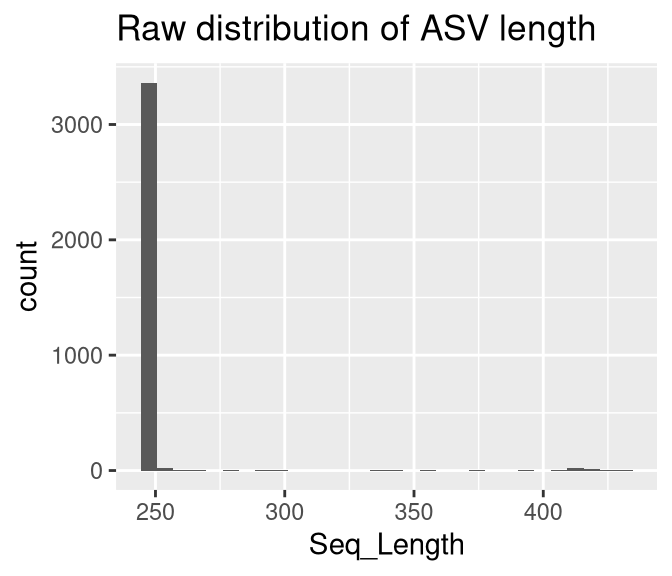

```r
# Inspect the distribution of sequence lengths of all ASVs in dataset
# AFTER TRIM
data.frame(Seq_Length = nchar(getSequences(raw_ASV_table))) %>%
  ggplot(aes(x = Seq_Length )) +
  geom_histogram() +
  labs(title = "Raw distribution of ASV length")
```

```r
###################################################
###################################################
# TRIM THE ASVS
# Let's trim the ASVs to only be the right size, which is 249.
# 249 originates from our expected amplicon of 252 - 3bp in the forward read due to low quality.

# We will allow for a few
raw_ASV_table_trimmed <- raw_ASV_table[,nchar(colnames(raw_ASV_table)) %in% 248:250]

# Inspect the distribution of sequence lengths of all ASVs in dataset
table(nchar(getSequences(raw_ASV_table_trimmed)))
```

```
##
##  248  249  250
##  179 3097   87
```

```r
# What proportion is left of the sequences?
sum(raw_ASV_table_trimmed)/sum(raw_ASV_table)
```

```
## [1] 0.9973974
```

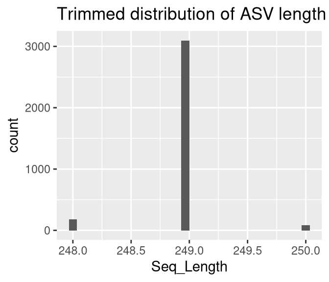

```r
# Inspect the distribution of sequence lengths of all ASVs in dataset
# AFTER TRIM
data.frame(Seq_Length = nchar(getSequences(raw_ASV_table_trimmed))) %>%
  ggplot(aes(x = Seq_Length )) +
  geom_histogram() +
  labs(title = "Trimmed distribution of ASV length")
```

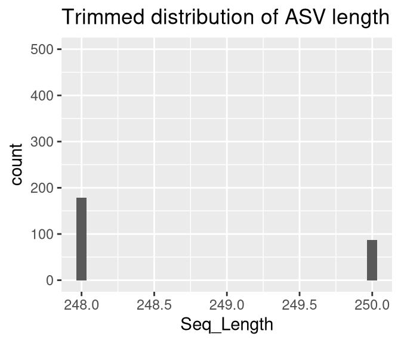

```r
# Note the peak at 249 is ABOVE 3000

# Let's zoom in on the plot
data.frame(Seq_Length = nchar(getSequences(raw_ASV_table_trimmed))) %>%
  ggplot(aes(x = Seq_Length )) +
  geom_histogram() +
  labs(title = "Trimmed distribution of ASV length") +
  scale_y_continuous(limits = c(0, 500))
```

Taking into account the lower, zoomed-in plot. Do we want to remove those extra ASVs?

# Remove Chimeras

Sometimes chimeras arise in our workflow.

**Chimeric sequences** are artificial sequences formed by the combination of two or more distinct biological sequences. These chimeric sequences can arise during the polymerase chain reaction (PCR) amplification step of the 16S rRNA gene, where fragments from different templates can be erroneously joined together.

Chimera removal is an essential step in the analysis of 16S sequencing data to improve the accuracy of downstream analyses, such as taxonomic assignment and diversity assessment. It helps to avoid the inclusion of misleading or spurious sequences that could lead to incorrect biological interpretations.

```r
# Remove the chimeras in the raw ASV table
noChimeras_ASV_table <- removeBimeraDenovo(raw_ASV_table_trimmed,
                                           method="consensus",
                                           multithread=TRUE, verbose=TRUE)
```

```
## Identified 283 bimeras out of 3363 input sequences.
```

```r
# Check the dimensions
dim(noChimeras_ASV_table)
```

```
## [1]   95 3080
```

```r
# What proportion is left of the sequences?
sum(noChimeras_ASV_table)/sum(raw_ASV_table_trimmed)
```

```
## [1] 0.9762963
```

```r
sum(noChimeras_ASV_table)/sum(raw_ASV_table)
```

```
## [1] 0.9737554
```

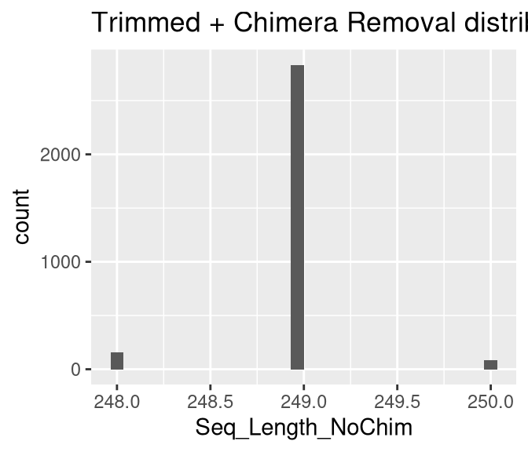

```r
# Plot it
data.frame(Seq_Length_NoChim = nchar(getSequences(noChimeras_ASV_table))) %>%
  ggplot(aes(x = Seq_Length_NoChim )) +
  geom_histogram()+
  labs(title = "Trimmed + Chimera Removal distribution of ASV length")
```

```r
# Note the difference in the peak at 249, which is now BELOW 3000
```

# Track the read counts

Here, we will look at the number of reads that were lost in the filtering, denoising, merging, and chimera removal.

```r
# A little function to identify number seqs
getN <- function(x) sum(getUniques(x))

# Make the table to track the seqs
track <- cbind(filtered_reads,
               sapply(dada_forward, getN),
               sapply(dada_reverse, getN),
               sapply(merged_ASVs, getN),
               rowSums(noChimeras_ASV_table))

head(track)
```

```
##                                            reads.in reads.out
## 022um-Control_S36_L001_R1_001.fastq.gz         8722      8023 8009 7975 7972
## 20210602-MA-ABB1F_S31_L001_R1_001.fastq.gz     5156      4632 4411 4366 4166
## 20210602-MA-ABB1P_S28_L001_R1_001.fastq.gz     5051      4597 4046 4010 3702
## 20210602-MA-ABB1W_S58_L001_R1_001.fastq.gz     7695      7023 6460 6424 6087
## 20210602-MA-ABS1F_S45_L001_R1_001.fastq.gz     5098      4595 4208 4180 3922
## 20210602-MA-ABS1P_S65_L001_R1_001.fastq.gz     5900      5314 4646 4663 4335
##
## 022um-Control_S36_L001_R1_001.fastq.gz     7972
## 20210602-MA-ABB1F_S31_L001_R1_001.fastq.gz 4143
## 20210602-MA-ABB1P_S28_L001_R1_001.fastq.gz 3657
## 20210602-MA-ABB1W_S58_L001_R1_001.fastq.gz 5999
## 20210602-MA-ABS1F_S45_L001_R1_001.fastq.gz 3874
## 20210602-MA-ABS1P_S65_L001_R1_001.fastq.gz 4324
```

```r
# Update column names to be more informative (most are missing at the moment!)
colnames(track) <- c("input", "filtered", "denoisedF", "denoisedR", "merged", "nochim")
rownames(track) <- samples

# Generate a dataframe to track the reads through our DADA2 pipeline
track_counts_df <-
  track %>%
  # make it a dataframe
  as.data.frame() %>%
  rownames_to_column(var = "names") %>%
  mutate(perc_reads_retained = 100 * nochim / input)

# Visualize it in table format
DT::datatable(track_counts_df)
```

|  | names | input | filtered | denoisedF | denoisedR | merged | nochim | perc_reads_retained |
| --- | --- | --- | --- | --- | --- | --- | --- | --- |
| 1 | 022um-Control | 8722 | 8023 | 8009 | 7975 | 7972 | 7972 | 91.40105480394405 |
| 2 | 20210602-MA-ABB1F | 5156 | 4632 | 4411 | 4366 | 4166 | 4143 | 80.35298681148177 |
| 3 | 20210602-MA-ABB1P | 5051 | 4597 | 4046 | 4010 | 3702 | 3657 | 72.40150465254405 |
| 4 | 20210602-MA-ABB1W | 7695 | 7023 | 6460 | 6424 | 6087 | 5999 | 77.95971410006497 |
| 5 | 20210602-MA-ABS1F | 5098 | 4595 | 4208 | 4180 | 3922 | 3874 | 75.99058454295802 |
| 6 | 20210602-MA-ABS1P | 5900 | 5314 | 4646 | 4663 | 4335 | 4324 | 73.28813559322033 |
| 7 | 20210602-MA-ABS1W | 6786 | 6145 | 5627 | 5629 | 5236 | 5121 | 75.46419098143237 |
| 8 | 20210602-MA-CEB1F | 6081 | 5489 | 5095 | 5056 | 4816 | 4789 | 78.75349449103766 |
| 9 | 20210602-MA-CEB1P | 7594 | 6954 | 6470 | 6464 | 6088 | 5517 | 72.64946010007901 |
| 10 | 20210602-MA-CEB1W | 7307 | 6599 | 6054 | 6097 | 5828 | 5736 | 78.50006842753524 |

[output cut: 85 more lines]

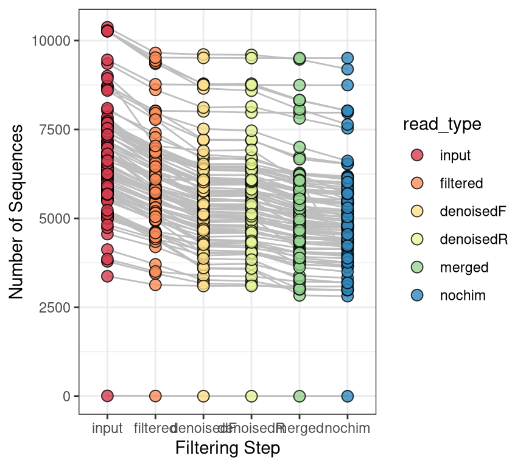

```r
# Plot it!
track_counts_df %>%
  pivot_longer(input:nochim, names_to = "read_type", values_to = "num_reads") %>%
  mutate(read_type = fct_relevel(read_type,
                                 "input", "filtered", "denoisedF", "denoisedR", "merged", "nochim")) %>%
  ggplot(aes(x = read_type, y = num_reads, fill = read_type)) +
  geom_line(aes(group = names), color = "grey") +
  geom_point(shape = 21, size = 3, alpha = 0.8) +
  scale_fill_brewer(palette = "Spectral") +
  labs(x = "Filtering Step", y = "Number of Sequences") +
  theme_bw()
```

# Assign Taxonomy

Here, we will use the silva database version 138!

```r
# The next line took 2 mins to run
taxa_train <-
  assignTaxonomy(noChimeras_ASV_table,
                 "/workdir/in_class_data/taxonomy/silva_nr99_v138.1_train_set.fa.gz",
                 multithread=TRUE)

# the next line took 3 minutes
taxa_addSpecies <-
  addSpecies(taxa_train,
             "/workdir/in_class_data/taxonomy/silva_species_assignment_v138.1.fa.gz")

# Inspect the taxonomy
taxa_print <- taxa_addSpecies # Removing sequence rownames for display only
rownames(taxa_print) <- NULL
#View(taxa_print)
```

# Prepare the data for export!

## 1. ASV Table

Below, we will prepare the following:

1. Two ASV Count tables:
   1. With ASV seqs: ASV headers include the *entire* ASV sequence ~250bps.
   2. with ASV names: This includes re-written and shortened headers like ASV_1, ASV_2, etc, which will match the names in our fasta file below.
2. `ASV_fastas`: A fasta file that we can use to build a tree for phylogenetic analyses (e.g. phylogenetic alpha diversity metrics or UNIFRAC dissimilarty).

### Finalize ASV Count Tables

```r
########### 2. COUNT TABLE ###############
############## Modify the ASV names and then save a fasta file!  ##############
# Give headers more manageable names
# First pull the ASV sequences
asv_seqs <- colnames(noChimeras_ASV_table)
asv_seqs[1:5]
```

```
## [1] "CGGGAGTGGCAAGCGTTATCCGGAATTATTGGGCGTAAAGCGTCCGCAGGCGGTCTGTCA…"
## [2] "CGGGAGTGGCAAGCGTTATCCGGAATTATTGGGCGTAAAGCGTCCGCAGGCGGTCTTGTA…"
## [3] "CAGAGGGTGCAAGCGTTAATCGGAATTACTGGGCGTAAAGCGCGCGTAGGTGGTTCGTTA…"
## [4] "GTAGGGGGCGAGCGTTGTCCGGATTTATTGGGCGTAAAGAGCTCGTAGGCGGTTCAACAA…"
## [5] "GTAGGGGGCGAGCGTTGTCCGGATTTATTGGGCGTAAAGAGCTCGTAGGCGGTTCAACAA…"
```

```r
# make headers for our ASV seq fasta file, which will be our asv names
asv_headers <- vector(dim(noChimeras_ASV_table)[2], mode = "character")
asv_headers[1:5]
```

```
## [1] "" "" "" "" ""
```

```r
# loop through vector and fill it in with ASV names
for (i in 1:dim(noChimeras_ASV_table)[2]) {
  asv_headers[i] <- paste(">ASV", i, sep = "_")
}

# intitution check
asv_headers[1:5]
```

```
## [1] ">ASV_1" ">ASV_2" ">ASV_3" ">ASV_4" ">ASV_5"
```

```r
##### Rename ASVs in table then write out our ASV fasta file!
#View(noChimeras_ASV_table)
asv_tab <- t(noChimeras_ASV_table)
#View(asv_tab)

## Rename our asvs!
row.names(asv_tab) <- sub(">", "", asv_headers)
#View(asv_tab)
```

## 2. Taxonomy Table

```r
# Inspect the taxonomy table
#View(taxa_addSpecies)

##### Prepare tax table
# Add the ASV sequences from the rownames to a column
new_tax_tab <-
  taxa_addSpecies%>%
  as.data.frame() %>%
  rownames_to_column(var = "ASVseqs")
head(new_tax_tab)
```

```
##                                                                                                                                                                                                                                                     ASVseqs
## 1 CGGGAGTGGCAAGCGTTATCCGGAATTATTGGGCGTAAAGCGTCCGCAGGCGGTCTGTCA…
## 2 CGGGAGTGGCAAGCGTTATCCGGAATTATTGGGCGTAAAGCGTCCGCAGGCGGTCTTGTA…
## 3 CAGAGGGTGCAAGCGTTAATCGGAATTACTGGGCGTAAAGCGCGCGTAGGTGGTTCGTTA…
## 4  GTAGGGGGCGAGCGTTGTCCGGATTTATTGGGCGTAAAGAGCTCGTAGGCGGTTCAACAA…
## 5  GTAGGGGGCGAGCGTTGTCCGGATTTATTGGGCGTAAAGAGCTCGTAGGCGGTTCAACAA…
## 6 CGGAAGGTCCAAGCGTTAATCGGAATTACTGGGCGTAAAGCGCGCGTAGGTGGTTTATTA…
##    Kingdom           Phylum               Class           Order
## 1 Bacteria    Cyanobacteria      Cyanobacteriia Synechococcales
## 2 Bacteria    Cyanobacteria      Cyanobacteriia Synechococcales
## 3 Bacteria   Proteobacteria Gammaproteobacteria Pseudomonadales
## 4 Bacteria Actinobacteriota      Acidimicrobiia Actinomarinales
## 5 Bacteria Actinobacteriota      Acidimicrobiia Actinomarinales
## 6 Bacteria   Proteobacteria Gammaproteobacteria Pseudomonadales
##             Family                   Genus Species
## 1     Cyanobiaceae      Cyanobium PCC-6307    <NA>
## 2     Cyanobiaceae      Cyanobium PCC-6307    <NA>
## 3 Pseudomonadaceae             Pseudomonas    <NA>
## 4 Actinomarinaceae Candidatus Actinomarina    <NA>
## 5 Actinomarinaceae Candidatus Actinomarina    <NA>
## 6      SAR86 clade                    <NA>    <NA>
```

```r
# intution check
stopifnot(new_tax_tab$ASVseqs == colnames(noChimeras_ASV_table))

# Now let's add the ASV names
rownames(new_tax_tab) <- rownames(asv_tab)
head(new_tax_tab)
```

```
##                                                                                                                                                                                                                                                         ASVseqs
## ASV_1 CGGGAGTGGCAAGCGTTATCCGGAATTATTGGGCGTAAAGCGTCCGCAGGCGGTCTGTCA…
## ASV_2 CGGGAGTGGCAAGCGTTATCCGGAATTATTGGGCGTAAAGCGTCCGCAGGCGGTCTTGTA…
## ASV_3 CAGAGGGTGCAAGCGTTAATCGGAATTACTGGGCGTAAAGCGCGCGTAGGTGGTTCGTTA…
## ASV_4  GTAGGGGGCGAGCGTTGTCCGGATTTATTGGGCGTAAAGAGCTCGTAGGCGGTTCAACAA…
## ASV_5  GTAGGGGGCGAGCGTTGTCCGGATTTATTGGGCGTAAAGAGCTCGTAGGCGGTTCAACAA…
## ASV_6 CGGAAGGTCCAAGCGTTAATCGGAATTACTGGGCGTAAAGCGCGCGTAGGTGGTTTATTA…
##        Kingdom           Phylum               Class           Order
## ASV_1 Bacteria    Cyanobacteria      Cyanobacteriia Synechococcales
## ASV_2 Bacteria    Cyanobacteria      Cyanobacteriia Synechococcales
## ASV_3 Bacteria   Proteobacteria Gammaproteobacteria Pseudomonadales
## ASV_4 Bacteria Actinobacteriota      Acidimicrobiia Actinomarinales
## ASV_5 Bacteria Actinobacteriota      Acidimicrobiia Actinomarinales
## ASV_6 Bacteria   Proteobacteria Gammaproteobacteria Pseudomonadales
##                 Family                   Genus Species
## ASV_1     Cyanobiaceae      Cyanobium PCC-6307    <NA>
## ASV_2     Cyanobiaceae      Cyanobium PCC-6307    <NA>
## ASV_3 Pseudomonadaceae             Pseudomonas    <NA>
## ASV_4 Actinomarinaceae Candidatus Actinomarina    <NA>
## ASV_5 Actinomarinaceae Candidatus Actinomarina    <NA>
## ASV_6      SAR86 clade                    <NA>    <NA>
```

```r
### Final prep of tax table. Add new column with ASV names
asv_tax <-
  new_tax_tab %>%
  # add rownames from count table for phyloseq handoff
  mutate(ASV = rownames(asv_tab)) %>%
  # Resort the columns with select
  dplyr::select(Kingdom, Phylum, Class, Order, Family, Genus, Species, ASV, ASVseqs)

head(asv_tax)
```

```
##        Kingdom           Phylum               Class           Order
## ASV_1 Bacteria    Cyanobacteria      Cyanobacteriia Synechococcales
## ASV_2 Bacteria    Cyanobacteria      Cyanobacteriia Synechococcales
## ASV_3 Bacteria   Proteobacteria Gammaproteobacteria Pseudomonadales
## ASV_4 Bacteria Actinobacteriota      Acidimicrobiia Actinomarinales
## ASV_5 Bacteria Actinobacteriota      Acidimicrobiia Actinomarinales
## ASV_6 Bacteria   Proteobacteria Gammaproteobacteria Pseudomonadales
##                 Family                   Genus Species   ASV
## ASV_1     Cyanobiaceae      Cyanobium PCC-6307    <NA> ASV_1
## ASV_2     Cyanobiaceae      Cyanobium PCC-6307    <NA> ASV_2
## ASV_3 Pseudomonadaceae             Pseudomonas    <NA> ASV_3
## ASV_4 Actinomarinaceae Candidatus Actinomarina    <NA> ASV_4
## ASV_5 Actinomarinaceae Candidatus Actinomarina    <NA> ASV_5
## ASV_6      SAR86 clade                    <NA>    <NA> ASV_6
##                                                                                                                                                                                                                                                         ASVseqs
## ASV_1 CGGGAGTGGCAAGCGTTATCCGGAATTATTGGGCGTAAAGCGTCCGCAGGCGGTCTGTCA…
## ASV_2 CGGGAGTGGCAAGCGTTATCCGGAATTATTGGGCGTAAAGCGTCCGCAGGCGGTCTTGTA…
## ASV_3 CAGAGGGTGCAAGCGTTAATCGGAATTACTGGGCGTAAAGCGCGCGTAGGTGGTTCGTTA…
## ASV_4  GTAGGGGGCGAGCGTTGTCCGGATTTATTGGGCGTAAAGAGCTCGTAGGCGGTTCAACAA…
## ASV_5  GTAGGGGGCGAGCGTTGTCCGGATTTATTGGGCGTAAAGAGCTCGTAGGCGGTTCAACAA…
## ASV_6 CGGAAGGTCCAAGCGTTAATCGGAATTACTGGGCGTAAAGCGCGCGTAGGTGGTTTATTA…
```

```r
# Intution check
stopifnot(asv_tax$ASV == rownames(asv_tax), rownames(asv_tax) == rownames(asv_tab))
```

# Write `01_DADA2` files

Now, we will write the files! We will write the following to the `data/01_DADA2/` folder. We will save both as files that could be submitted as supplements AND as .RData objects for easy loading into the next steps into R.:

```r
# FIRST, we will save our output as regular files, which will be useful later on.
# Save to regular .tsv file
# Write BOTH the modified and unmodified ASV tables to a file!
# Write count table with ASV numbered names (e.g. ASV_1, ASV_2, etc)
write.table(asv_tab, "data/01_DADA2/ASV_counts.tsv", sep = "\t", quote = FALSE, col.names = NA)
# Write count table with ASV sequence names
write.table(noChimeras_ASV_table, "data/01_DADA2/ASV_counts_withSeqNames.tsv", sep = "\t", quote = FALSE, col.names = NA)
# Write out the fasta file for reference later on for what seq matches what ASV
asv_fasta <- c(rbind(asv_headers, asv_seqs))
# Save to a file!
write(asv_fasta, "data/01_DADA2/ASVs.fasta")


# SECOND, let's save the taxonomy tables
# Write the table
write.table(asv_tax, "data/01_DADA2/ASV_taxonomy.tsv", sep = "\t", quote = FALSE, col.names = NA)


# THIRD, let's save to a RData object
# Each of these files will be used in the analysis/02_Taxonomic_Assignment
# RData objects are for easy loading :)
save(noChimeras_ASV_table, file = "data/01_DADA2/noChimeras_ASV_table.RData")
save(asv_tab, file = "data/01_DADA2/ASV_counts.RData")
# And save the track_counts_df a R object, which we will merge with metadata information in the next step of the analysis in nalysis/02_Taxonomic_Assignment.
save(track_counts_df, file = "data/01_DADA2/track_read_counts.RData")
```